# Linear&NonLinear_Course_Project

Duo Zhou

8/14/2020

## Step 1

```r
library(dplyr)
library(MASS)
library(pscl)
```

### 1 Problem Description

Business analytics group of a manufacturing company is asked to investigate causes of malfunctions in technological process at one of the plants that result in significant increase of cost for the end product of the business. One of suspected reasons for malfunctions is deviation of temperature in burning zone from optimal levels. The sample in the provided file contains times of malfunctions in seconds since the start of measurement and records of temperature.

### 2 Data

File MScA_LinearNonLinear_CourseProject.csv contains time stamps of malfunction events expressed in seconds and temperature readings at the time of each event. Temperature sensor updates readings once a minute.

Read and prepare the data.

```r
dataPath<-"C:/Users/zd000/Desktop/MSCA/Linear&NonLinear/Course_Project/"
Course.Project.Data <-read.csv(paste(dataPath,"Course_Project.csv",
                                       sep="/"),header=T)
counting_process<-as.data.frame(cbind(Time=Course.Project.Data$Time,                                      Count=1:length(Course.Project.Data$Time)))
counting_process[1:10,]
```

```
##         Time Count
## 1   4.460672     1
## 2  15.542545     2
## 3  16.750386     3
## 4  38.709795     4
## 5  39.952442     5
## 6  41.320898     6
## 7  55.375259     7
## 8  61.855321     8
## 9  66.464590     9
## 10 66.966965    10
```

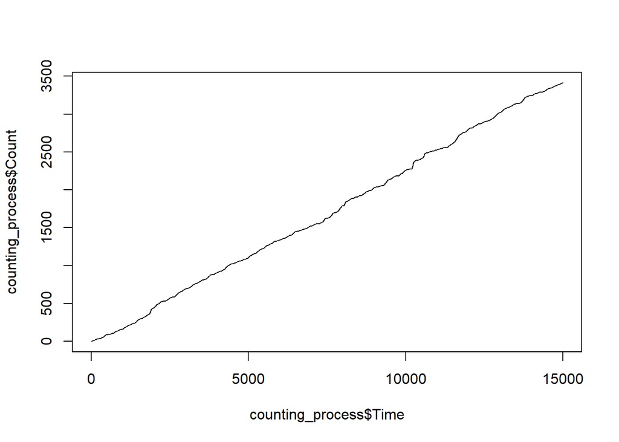

```r
plot(counting_process$Time,counting_process$Count,type="s")
```

The counting process trajectory looks pretty smooth and grows steadily. This may mean that malfunctions are caused by a persistent rather than episodic problem.

### 2.2 Cumulative intensity

Explore cumulative intensity of the process.

Cumulative intensity is calculated as Λ(t)=Nt/t, where Nt is the number of events during the time interval [0,t]. For this project t is sequence of time stamps and Nt is event count up until t.

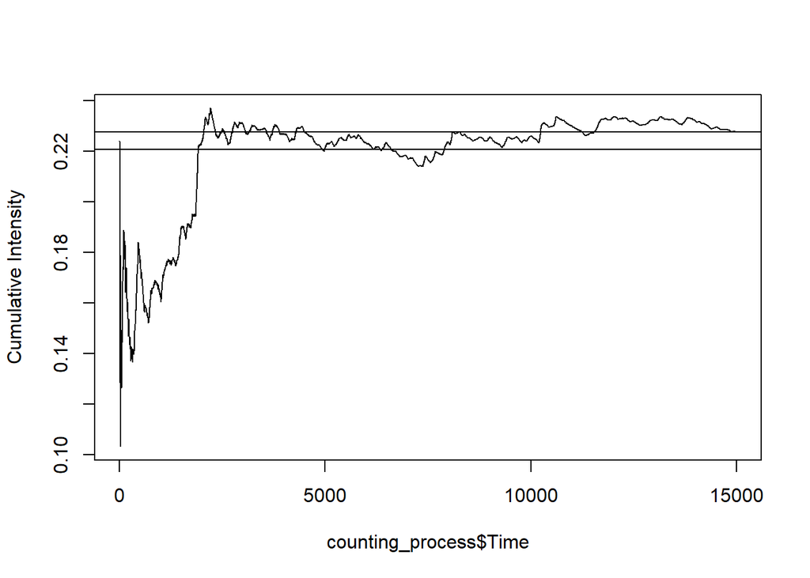

```r
plot(counting_process$Time,
     counting_process$Count/counting_process$Time,type="l",
     ylab="Cumulative Intensity")
abline(h=counting_process$Count[length(counting_process$Count)]/
         counting_process$Time[length(counting_process$Time)])
abline(h=mean(counting_process$Count/counting_process$Time))
```

The two horizontal lines on the graph are at the mean cumulative intensity and last cumulative intensity levels.

The cumulative intensity seems to converge to a stable level.

```r
c(Last.Intensity=counting_process$Count[length(counting_process$Count)]/
         counting_process$Time[length(counting_process$Time)],
  Mean.Intensity=mean(counting_process$Count/counting_process$Time))
```

```
## Last.Intensity Mean.Intensity
##      0.2276449      0.2206848
```

### 2.3 Minute data

Create dataframe ‘minute_data’ containing one-minute event counts and temperatures.

For example, look at the first rows of the data:

```r
Course.Project.Data[1:25,]
```

```
##          Time Temperature
## 1    4.460672    96.32332
## 2   15.542545    96.32332
## 3   16.750386    96.32332
## 4   38.709795    96.32332
## 5   39.952442    96.32332
## 6   41.320898    96.32332
## 7   55.375259    96.32332
## 8   61.855321   100.47791
## 9   66.464590   100.47791
## 10  66.966965   100.47791
## 11  76.100513   100.47791
## 12  76.617365   100.47791
## 13  77.186545   100.47791
## 14  83.032157   100.47791
## 15  87.772441   100.47791
## 16  91.786988   100.47791
## 17  98.161933   100.47791
## 18 101.258411   100.47791
## 19 105.186097   100.47791
## 20 105.928643   100.47791
## 21 111.476967   100.47791
## 22 119.426046   100.47791
## 23 124.406232    92.70218
## 24 135.352858    92.70218
## 25 136.545958    92.70218
```

Time column of the data is in seconds. First 7 rows (events) occurred during the first minute: time stamps are between 0 and 60. Temperature during the first minute was 96.3233199°F. The following 15 rows are in the second minute and the second minute temperature is 100.4779092°F.

Create dataframe ‘minute_data’. Each row corresponds to one minute of observations, it contains count of events during that minute and the temperature.

Some minutes may not contain any events. Rows corresponding to such minutes should be excluded from the dataframe.

```r
Course.Project.Data$minute<-floor(Course.Project.Data$Time/60)+1
minute_data<-Course.Project.Data %>%
  group_by(minute) %>%
  summarize( count=n(), temperature = mean(Temperature))

minute_data[minute_data['minute']==229,]
```

```
## # A tibble: 1 x 3
##   minute count temperature
##    <dbl> <int>       <dbl>
## 1    229    31        107.
```

### Step 2

```r
test_dat <- read.table(paste(dataPath,'step2_sample.csv',sep = '/'), header=TRUE)
```

Method 1

```r
Test.Deviance.Overdispersion.Poisson<-function(my.Sample){
  Model<-glm(my.Sample~1,family=poisson)
  Dev<-Model$deviance
  Deg.Fred<-Model$df.residual
  qch<-qchisq(c(.025,.975), df=Deg.Fred, lower.tail=FALSE)
  upper.limit<-(Deg.Fred)+sqrt(2*Deg.Fred)*1.96
  lower.limit<-(Deg.Fred)-sqrt(2*Deg.Fred)*1.96
  ans<-((Dev-Deg.Fred)/sqrt(2*Deg.Fred)>-1.96)&((Dev-Deg.Fred)/sqrt(2*Deg.Fred)<1.96)
  return(cbind(Dev, upper.limit,lower.limit, log=ans,qch[1],qch[2]))
}
Test.Deviance.Overdispersion.Poisson(test_dat$count)
```

```
##           Dev upper.limit lower.limit log
## [1,] 513.0266    560.9186    437.0814   1 562.7895 438.998
```

```r
Test.Deviance.Overdispersion.Poisson(minute_data$count)
```

```
##           Dev upper.limit lower.limit log
## [1,] 1832.137    292.7392    205.2608   0 294.6008 207.1856
```

Method 2

```r
AER::dispersiontest(glm(test_dat$count~1,family="poisson"),alternative="two.sided")
```

```
##
##  Dispersion test
##
## data:  glm(test_dat$count ~ 1, family = "poisson")
## z = 0.29368, p-value = 0.769
## alternative hypothesis: true dispersion is not equal to 1
## sample estimates:
## dispersion
##   1.019478
```

```r
AER::dispersiontest(glm(minute_data$count~1,family="poisson"),alternative="two.sided")
```

```
##
##  Dispersion test
##
## data:  glm(minute_data$count ~ 1, family = "poisson")
## z = 4.2697, p-value = 1.957e-05
## alternative hypothesis: true dispersion is not equal to 1
## sample estimates:
## dispersion
##   8.694908
```

```r
NB.model.pois<-glm.nb(test_dat$count~1)
odTest(NB.model.pois)
```

```
## Likelihood ratio test of H0: Poisson, as restricted NB model:
## n.b., the distribution of the test-statistic under H0 is non-standard
## e.g., see help(odTest) for details/references
##
## Critical value of test statistic at the alpha= 0.05 level: 2.7055
## Chi-Square Test Statistic =  0.093 p-value = 0.3802
```

```r
NB.model.pois1<-glm.nb(minute_data$count~1)
odTest(NB.model.pois1)
```

```
## Likelihood ratio test of H0: Poisson, as restricted NB model:
## n.b., the distribution of the test-statistic under H0 is non-standard
## e.g., see help(odTest) for details/references
##
## Critical value of test statistic at the alpha= 0.05 level: 2.7055
## Chi-Square Test Statistic =  1099.3847 p-value = < 2.2e-16
```

### 4 Analyses of distributions of variables

4.1 Find distribution of Poisson intensity. 4.1.1 Kolmlgorov-Smirnov test. Kolmogorov-Smirnov test is used to test hypotheses of equivalence between two empirical distributions or equivalence between one empirical distribution and one theoretical distribution.

```r
library(lattice)
library(latticeExtra)
```

```r
fitExp <- MASS::fitdistr(counting_process$Time, "exponential")
KSTest_event_intervals <- ks.test(counting_process$Time, "pexp", rate=fitExp$estimate)
c(KSTest_event_intervals$statistic,p.value=KSTest_event_intervals$p.value)
```

```
##         D   p.value
## 0.1639568 0.0000000
```

Intensity

```r
event_intensities = minute_data$count
# Normal
fit.norm = MASS::fitdistr(event_intensities, densfun='normal')
ks.test(event_intensities,"pnorm",mean=fit.norm$estimate[1],sd=fit.norm$estimate[2])
```

```
##
##  One-sample Kolmogorov-Smirnov test
##
## data:  event_intensities
## D = 0.15707, p-value = 8.78e-06
## alternative hypothesis: two-sided
```

```r
# D = 0.15707, p-value = 8.78e-06

# Exponential
fit.exp = MASS::fitdistr(event_intensities, densfun = "exponential")
ks.test(event_intensities, "pexp", rate = fit.exp$estimate)
```

```
##
##  One-sample Kolmogorov-Smirnov test
##
## data:  event_intensities
## D = 0.17956, p-value = 1.996e-07
## alternative hypothesis: two-sided
```

```r
# D = 0.17956, p-value = 1.996e-07

# Gamma
fit.gam = MASS::fitdistr(event_intensities, densfun="gamma")
ks.test(event_intensities, "pgamma", shape=fit.gam$estimate[1], rate=fit.gam$estimate[2])
```

```
##
##  One-sample Kolmogorov-Smirnov test
##
## data:  event_intensities
## D = 0.076201, p-value = 0.1097
## alternative hypothesis: two-sided
```

```r
# D = 0.076201, p-value = 0.1097

# Log Normal
fit.lognorm = MASS::fitdistr(event_intensities, densfun = "lognormal")
ks.test(event_intensities, "plnorm", meanlog=fit.lognorm$estimate[1], sdlog=fit.lognorm$estimate[2])
```

```
##
##  One-sample Kolmogorov-Smirnov test
##
## data:  event_intensities
## D = 0.12003, p-value = 0.001488
## alternative hypothesis: two-sided
```

```r
# D = 0.12003, p-value = 0.001488

# Logistic
fit.logit = MASS::fitdistr(event_intensities, densfun="logistic")
ks.test(event_intensities, "plogis", location=fit.logit$estimate[1], scale=fit.logit$estimate[2])
```

```
##
##  One-sample Kolmogorov-Smirnov test
##
## data:  event_intensities
## D = 0.10735, p-value = 0.006287
## alternative hypothesis: two-sided
```

```r
# D = 0.10735, p-value = 0.006287
```

Temperature

```r
# Fit the same five candidates on temperature
temps = minute_data$temperature

# Normal
fit.norm = MASS::fitdistr(temps, densfun='normal')
ks.test(temps,"pnorm",mean=fit.norm$estimate[1],sd=fit.norm$estimate[2])
```

```
##
##  One-sample Kolmogorov-Smirnov test
##
## data:  temps
## D = 0.041953, p-value = 0.7711
## alternative hypothesis: two-sided
```

```r
# D = 0.041953, p-value = 0.7711

# Exponential
fit.exp = MASS::fitdistr(temps, densfun = "exponential")
ks.test(temps, "pexp", rate = fit.exp$estimate)
```

```
##
##  One-sample Kolmogorov-Smirnov test
##
## data:  temps
## D = 0.57975, p-value < 2.2e-16
## alternative hypothesis: two-sided
```

```r
# D = 0.57975, p-value < 2.2e-16

# Gamma
fit.gam = MASS::fitdistr(temps, densfun="gamma")
ks.test(temps, "pgamma", shape=fit.gam$estimate[1], rate=fit.gam$estimate[2])
```

```
##
##  One-sample Kolmogorov-Smirnov test
##
## data:  temps
## D = 0.048746, p-value = 0.5924
## alternative hypothesis: two-sided
```

```r
# D = 0.048746, p-value = 0.5924

# Log Normal
fit.lognorm = MASS::fitdistr(temps, densfun = "lognormal")
ks.test(temps, "plnorm", meanlog=fit.lognorm$estimate[1], sdlog=fit.lognorm$estimate[2])
```

```
##
##  One-sample Kolmogorov-Smirnov test
##
## data:  temps
## D = 0.052065, p-value = 0.5069
## alternative hypothesis: two-sided
```

```r
# D = 0.052065, p-value = 0.5069

# Logistic
fit.logit = MASS::fitdistr(temps, densfun="logistic")
ks.test(temps, "plogis", location=fit.logit$estimate[1], scale=fit.logit$estimate[2])
```

```
##
##  One-sample Kolmogorov-Smirnov test
##
## data:  temps
## D = 0.038929, p-value = 0.8431
## alternative hypothesis: two-sided
```

```r
# D = 0.038929, p-value = 0.8431
```

```r
fit.logit$estimate[1]
```

```
## location
## 100.2795
```

```r
fit.logit$estimate[2]
```

```
##   scale
## 2.95652
```

```r
fit.norm$estimate[1]
```

```
##     mean
## 100.2008
```

```r
fit.norm$estimate[2]
```

```
##       sd
## 5.221083
```

```r
fit.gam$estimate[1]
```

```
##    shape
## 366.8433
```

```r
fit.gam$estimate[2]
```

```
##     rate
## 3.661081
```

```r
fit.lognorm$estimate[1]
```

```
## meanlog
## 4.60581
```

```r
fit.lognorm$estimate[2]
```

```
##      sdlog
## 0.05236869
```

```r
fit.intensity.gam = MASS::fitdistr(event_intensities, densfun="gamma")
fit.temp.norm = MASS::fitdistr(temps, densfun='normal')
distrParam <- list(intensity=fit.intensity.gam, temperature=fit.temp.norm)
distrParam
```

```
## $intensity
##      shape         rate
##   1.73511795   0.12705900
##  (0.14276677) (0.01210372)
##
## $temperature
##       mean           sd
##   100.2008143     5.2210835
##  (  0.3302103) (  0.2334940)
```

```r
part2_data<-minute_data
head(part2_data)
```

```
## # A tibble: 6 x 3
##   minute count temperature
##    <dbl> <int>       <dbl>
## 1      1     7        96.3
## 2      2    15       100.
## 3      3     7        92.7
## 4      4     6        89.5
## 5      5     6        92.2
## 6      6     9       100.
```

```r
library(copula)
```

```r
part2_data<-part2_data[complete.cases(part2_data),]
part2_data$intensity<-part2_data$count
head(part2_data)
```

```
## # A tibble: 6 x 4
##   minute count temperature intensity
##    <dbl> <int>       <dbl>     <int>
## 1      1     7        96.3         7
## 2      2    15       100.         15
## 3      3     7        92.7         7
## 4      4     6        89.5         6
## 5      5     6        92.2         6
## 6      6     9       100.          9
```

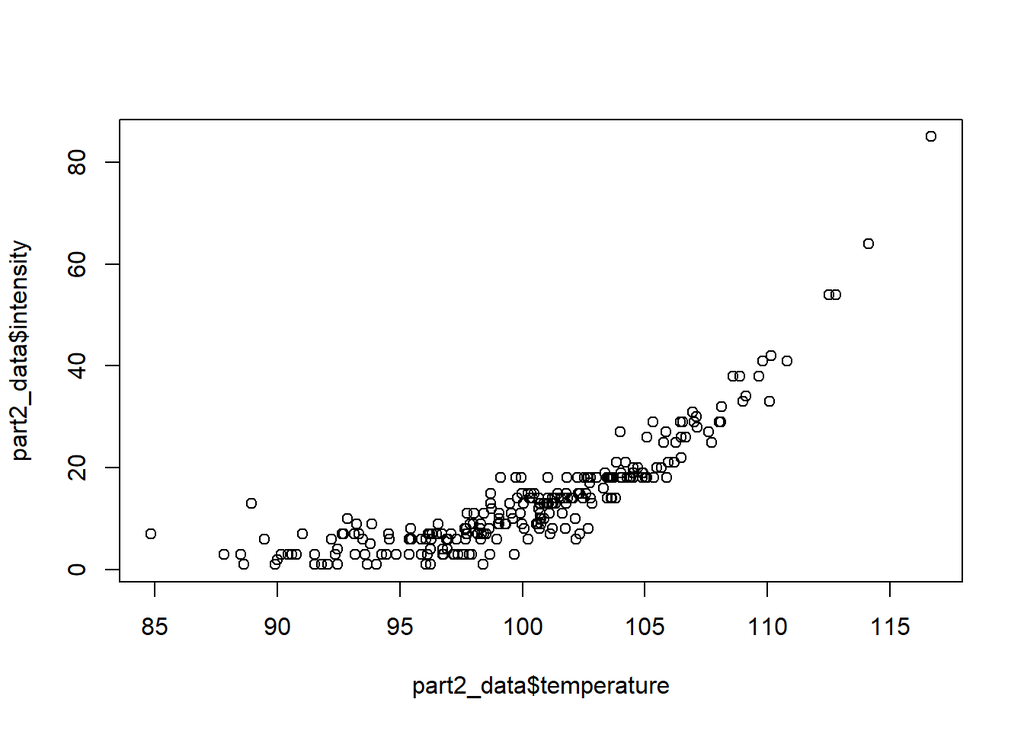

```r
plot(part2_data$temperature,part2_data$intensity)
```

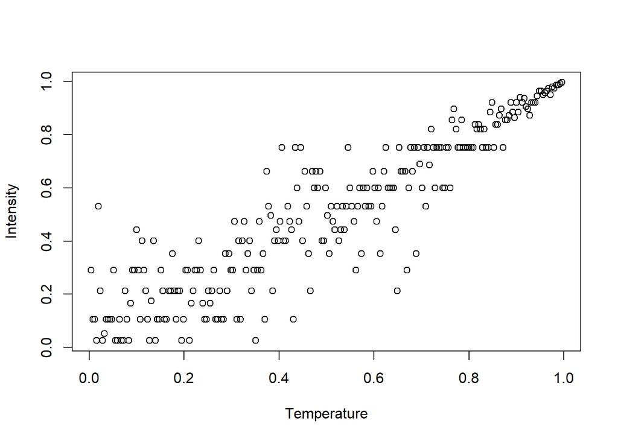

```r
plot(rank(part2_data$temperature)/(dim(part2_data)[1]+1),
     rank(part2_data$intensity)/(dim(part2_data)[1]+1),xlab="Temperature",ylab="Intensity")
```

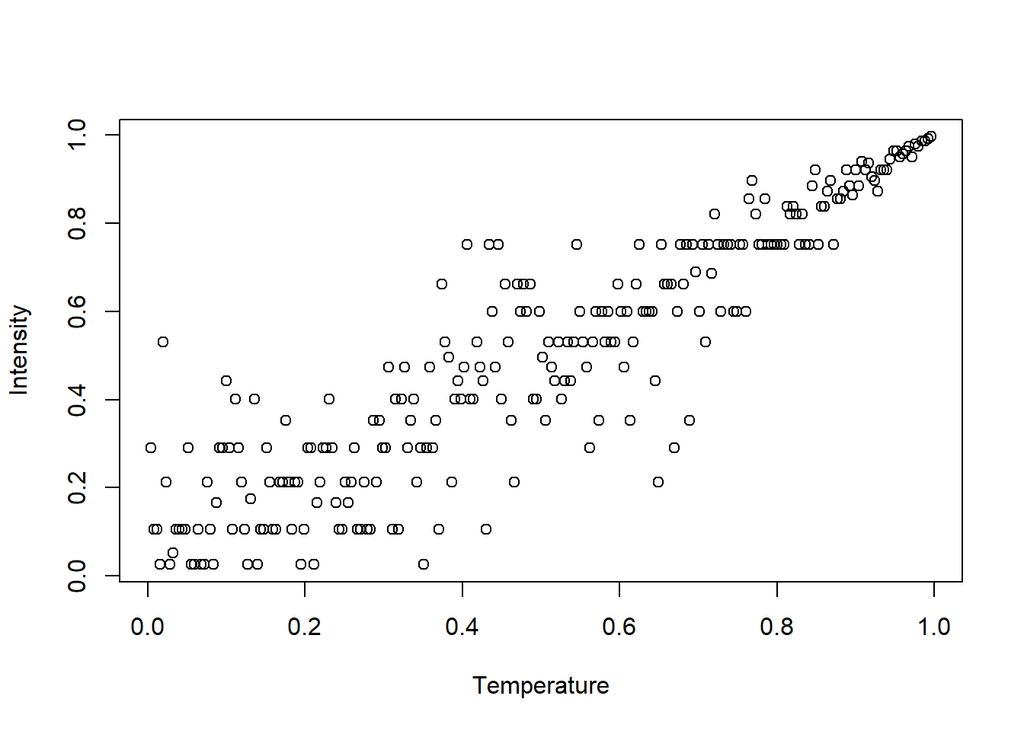

```r
plot(pobs(part2_data[,c("temperature","intensity")]),xlab="Temperature",ylab="Intensity")
```

# Part 1 - Fit Parametric Copulas

Normal, Gumbel, Clayton, Frank Compare likelihood values for different parametric copulas and select the best of them

```r
copula_data <- copula::pobs(part2_data[,c("temperature","intensity")])

fit.copula.normal <- fitCopula(
  copula = normalCopula(),
  data = copula_data,
  method = "ml",
  optim.method = "BFGS")
fit.copula.normal@loglik
```

```
## [1] 198.146
```

```r
# 198.146

fit.copula.gumbel <- fitCopula(
  copula = gumbelCopula(),
  data = copula_data,
  method = "ml",
  optim.method = "BFGS")
fit.copula.gumbel@loglik
```

```
## [1] 247.0918
```

```r
# 247.092

fit.copula.clayton <- fitCopula(
  copula = claytonCopula(),
  data = 1-copula_data,
  method = "ml",
  optim.method = "BFGS")
fit.copula.clayton@loglik
```

```
## [1] 259.9733
```

```r
# 111.659 -- wrong for some reason
# 259.973

fit.copula.frank <- fitCopula(
  copula = frankCopula(),
  data = copula_data,
  method = "ml",
  optim.method = "BFGS")
fit.copula.frank@loglik
```

```
## [1] 211.5144
```

```r
# 211.514
```

2 Copula quantile regression Plot the selected parametric copula using functions persp() and contour()

Recall marginal distributions of the data. They play important role in copula quantile regression.

Load parameters of the marginal distributions of temperature and event intensity fitted to the data in Part 1.

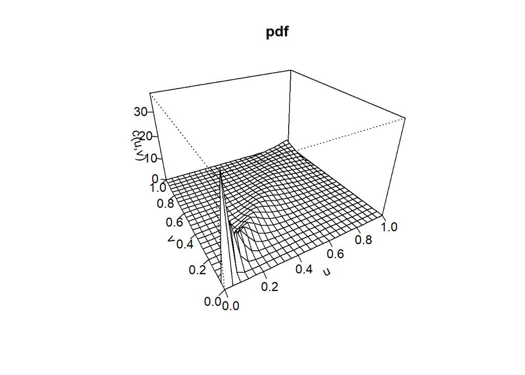

```r
alphaClayton = summary(fit.copula.clayton)$coefficients[1]
copulaClayton_sim <- claytonCopula(param=alphaClayton,dim=2)
persp(copulaClayton_sim, dCopula, main="pdf",xlab="u", ylab="v", zlab="c(u,v)")
```

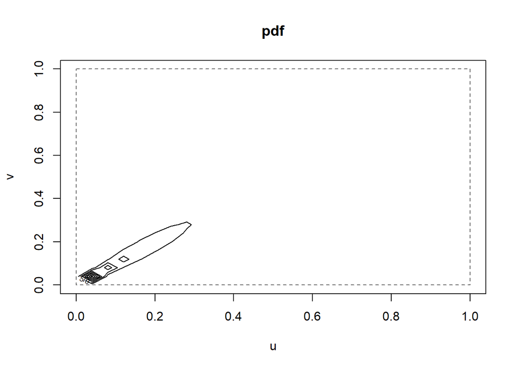

```r
contour(copulaClayton_sim,dCopula, main="pdf",xlab="u", ylab="v")
```

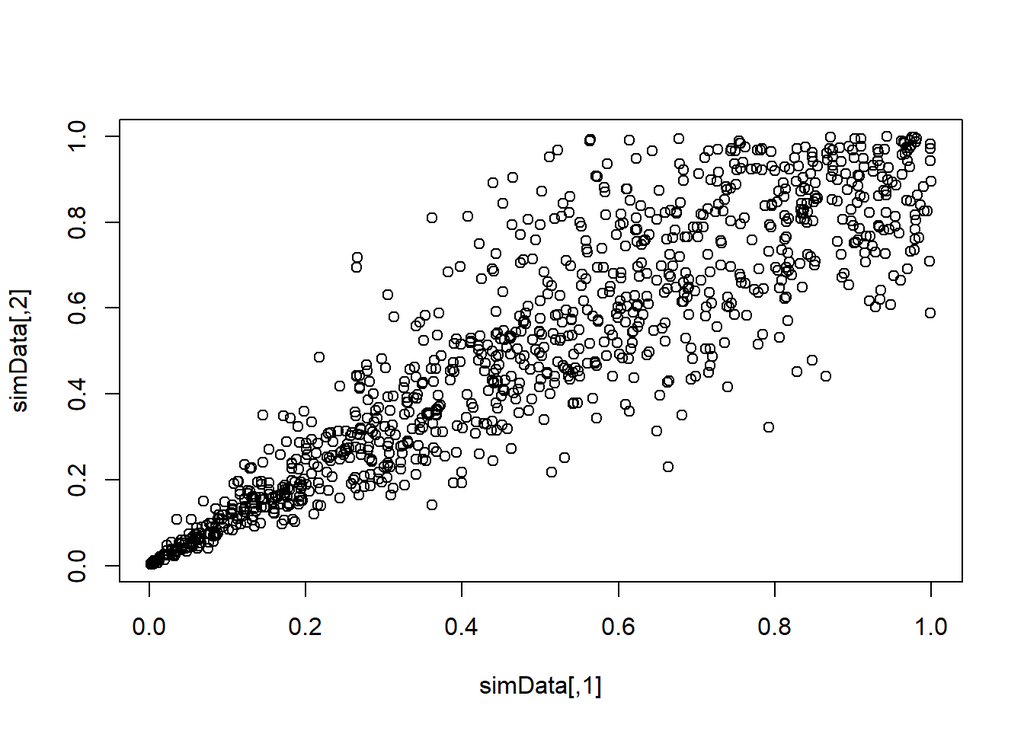

```r
simData<-rCopula(1000,copulaClayton_sim)
plot(simData)
```

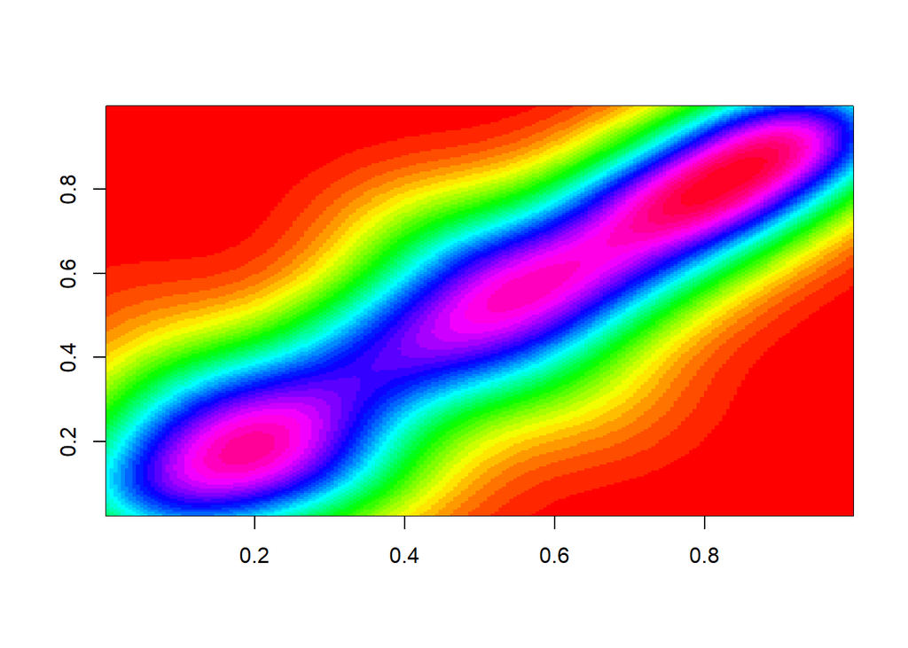

```r
k <- kde2d(copula_data[,1], copula_data[,2], n=200)
image(k,col=rainbow(40))
```

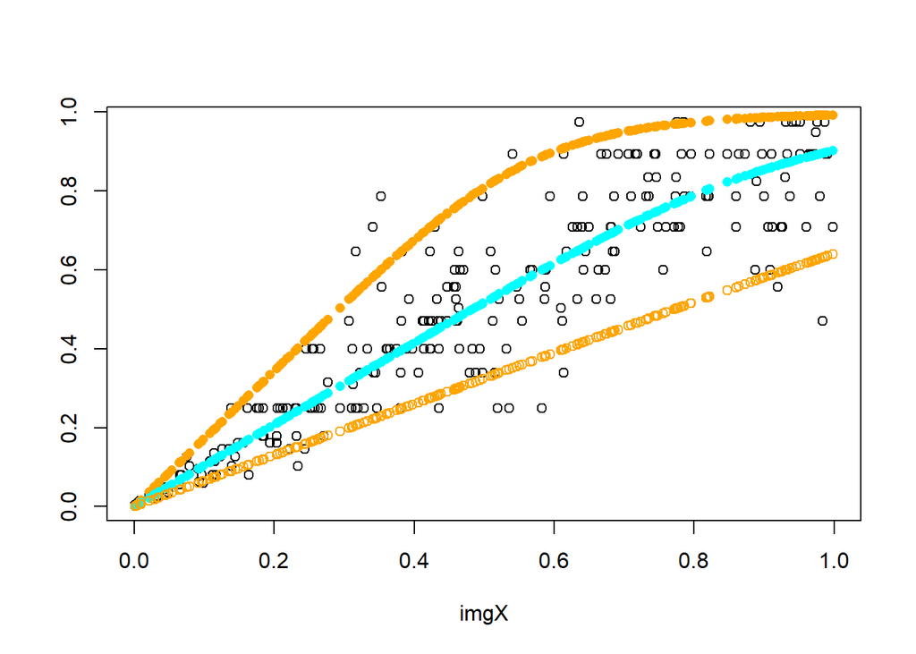

```r
# Follow the steps of copula quantile regression:

# 1. Calculate copula image of the predictor imgX using the marginal
#    distribution fitted to the data in Part 1
temp_mean = distrParam$temperature$estimate[1]
temp_sd = distrParam$temperature$estimate[2]

imgX <- pnorm(part2_data$temperature, mean=temp_mean, sd=temp_sd)

# 2. If the copula needs to be inverted from upper tail to lower tail or
#    vice versa, rotate the image by imgX <- -imgX+1
copulat_data_rot = 1-copula_data
imgX <- 1-imgX


# 3. Calculate image quantiles of conditional distribution V|U corresponding
#    to the selected copula type, its parameter and every point of
#    imgX (image of X) for levels 5%, 95% and 50% (median). Use formulas given
#    in the lecture for quantiles of conditional distributions corresponding to
#    different copula types

qclayton <- function(X, alpha_, theta_) {
  # Clayton conditional distribution quantile
  ((alpha_**(-theta_/(1+theta_)) - 1) * X**(-theta_) + 1) ** (-1/theta_)
}

theta <- fit.copula.clayton@estimate

intensity.Q.Low  <- qclayton(imgX, alpha_=0.95, theta_=theta)
intensity.Q.Mid  <- qclayton(imgX, alpha_=0.50, theta_=theta)
intensity.Q.High <- qclayton(imgX, alpha_=0.05, theta_=theta)

plot(cbind(imgX, copulat_data_rot[,2]))
points(imgX,intensity.Q.Low,col="orange",pch=16)
points(imgX,intensity.Q.Mid,col="cyan",pch=16)
points(imgX,intensity.Q.High,col="orange")
```

```r
# 4. Reconstruct quantiles for the original data units from the image quantiles
#   using marginal distributions fitted to the variables. Remember to rotate
#   image before reconstructing if necessary

intensity.Q.Low  = 1 - intensity.Q.Low
intensity.Q.Mid  = 1 - intensity.Q.Mid
intensity.Q.High = 1 - intensity.Q.High

fitted_shape = distrParam$intensity$estimate[1]
fitted_rate  = distrParam$intensity$estimate[2]

intensLow  = qgamma(intensity.Q.Low,  shape=fitted_shape, rate=fitted_rate)
intensMid  = qgamma(intensity.Q.Mid,  shape=fitted_shape, rate=fitted_rate)
intensHigh = qgamma(intensity.Q.High, shape=fitted_shape, rate=fitted_rate)
```

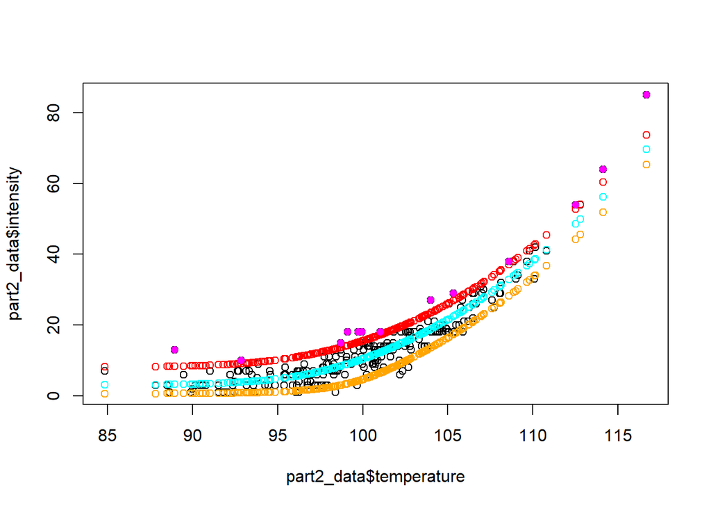

```r
# 5. Use reconstructed quantiles as predictions of conditional quantiles of
#    Y given X. In particular, predict Y by the 50% quantile (median)

lowMidHigh = data.frame(
  "intensLow" = intensLow,
  "intensMid" = intensMid,
  "intensHigh" = intensHigh
  )

df <- cbind(part2_data, lowMidHigh)
anomalies <- df[df$intensity > df$intensHigh,]

plot(part2_data$temperature,part2_data$intensity)
points(part2_data$temperature,lowMidHigh[,"intensLow"],col="orange")
points(part2_data$temperature,lowMidHigh[,"intensHigh"],col="red")
points(part2_data$temperature,lowMidHigh[,"intensMid"],col="cyan")
points(part2_data$temperature[anomalies$minute],
       part2_data$intensity[anomalies$minute],col="magenta",pch=16)
```

## Step 5

```r
dat <- readRDS(paste(dataPath,'step_5_data.rds',sep = '/'))
dat$predictor_DistrType
```

```
## [1] "logistic"
```

```r
dat$output_DistrType
```

```
## [1] "lognormal"
```

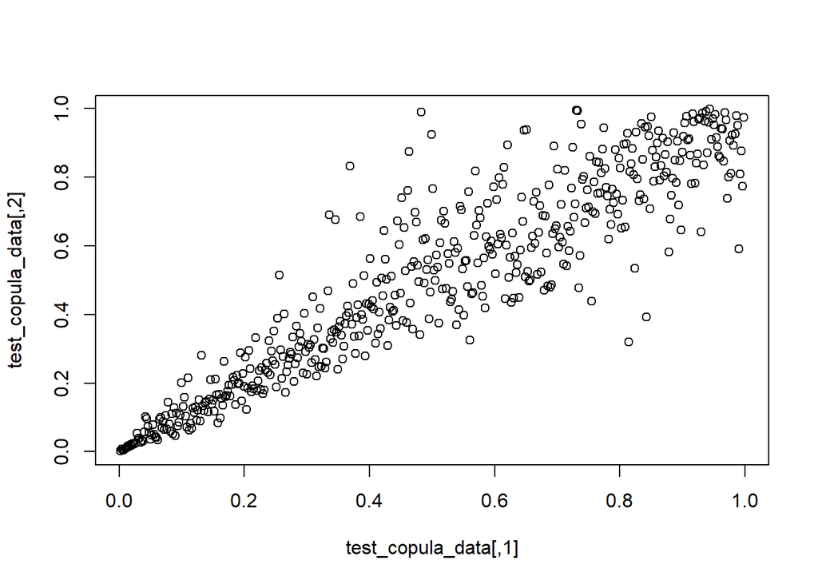

```r
test_copula_data = pobs(cbind(dat$predictor, dat$output))
plot(test_copula_data)
```

```r
test_imgX <- plogis(dat$predictor, location=dat$predictor_DistrParameters[1], scale=dat$predictor_DistrParameters[2])


fit.copula.clayton.test <- fitCopula(
  copula = claytonCopula(),
  data = test_copula_data,
  method = "ml",
  optim.method = "BFGS")
fit.copula.clayton.test@loglik
```

```
## [1] 562.7038
```

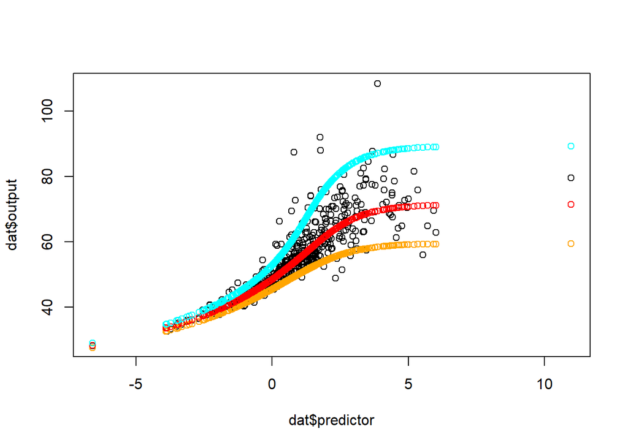

```r
theta <- fit.copula.clayton.test@estimate
qclayton <- function(X, alpha_, theta_) {
  # Clayton conditional distribution quantile
  ((alpha_**(-theta_/(1+theta_)) - 1) * X**(-theta_) + 1) ** (-1/theta_)
}
test.output.Q.Low  <- qclayton(test_imgX, alpha_=0.05, theta_=theta)
test.output.Q.Mid  <- qclayton(test_imgX, alpha_=0.50, theta_=theta)
test.output.Q.High <- qclayton(test_imgX, alpha_=0.95, theta_=theta)

test_fitted_mean = dat$output_DistrParameters[1]
test_fitted_sd = dat$output_DistrParameters[2]

test.output.Low  = qlnorm(test.output.Q.Low,  meanlog=test_fitted_mean, sdlog=test_fitted_sd)
test.output.Mid  = qlnorm(test.output.Q.Mid,  meanlog=test_fitted_mean, sdlog=test_fitted_sd)
test.output.High = qlnorm(test.output.Q.High, meanlog=test_fitted_mean, sdlog=test_fitted_sd)

plot(dat$predictor,dat$output)
points(dat$predictor,test.output.Low,col="orange")
points(dat$predictor,test.output.Mid,col="red")
points(dat$predictor,test.output.High,col="cyan")
```

```r
res <- list(anomalies_temperature = anomalies$temperature,
            anomalies_intensity = anomalies$intensity,
            copulaType = "clayton",
            quantileLow=test.output.Low,
            quantileMid=test.output.Mid,
            quantileHigh=test.output.High
)
saveRDS(res, file = paste(dataPath,'result5.rds',sep = '/'))
```

## Step 6

```r
# Step 6 - Count Regression
poission.model <- glm(intensity ~ temperature, family=poisson(link='log'), data=part2_data)

summary(poission.model)
```

```
##
## Call:
## glm(formula = intensity ~ temperature, family = poisson(link = "log"),
##     data = part2_data)
##
## Deviance Residuals:
##     Min       1Q   Median       3Q      Max
## -3.3017  -0.5683   0.0201   0.4998   4.6363
##
## Coefficients:
##               Estimate Std. Error z value Pr(>|z|)
## (Intercept) -10.577091   0.337474  -31.34   <2e-16 ***
## temperature   0.129382   0.003249   39.82   <2e-16 ***
## ---
## Signif. codes:  0 '***' 0.001 '**' 0.01 '*' 0.05 '.' 0.1 ' ' 1
##
## (Dispersion parameter for poisson family taken to be 1)
##
##     Null deviance: 1832.14  on 249  degrees of freedom
## Residual deviance:  272.79  on 248  degrees of freedom
## AIC: 1317.6
##
## Number of Fisher Scoring iterations: 4
```

```r
summary(poission.model)$deviance
```

```
## [1] 272.7861
```

```r
# 272.786, 248

nb.model <- MASS::glm.nb(intensity ~ temperature, data=part2_data)
summary(nb.model)
```

```
##
## Call:
## MASS::glm.nb(formula = intensity ~ temperature, data = part2_data,
##     init.theta = 97524.05631, link = log)
##
## Deviance Residuals:
##     Min       1Q   Median       3Q      Max
## -3.3016  -0.5682   0.0201   0.4998   4.6362
##
## Coefficients:
##              Estimate Std. Error z value Pr(>|z|)
## (Intercept) -10.57716    0.33753  -31.34   <2e-16 ***
## temperature   0.12938    0.00325   39.81   <2e-16 ***
## ---
## Signif. codes:  0 '***' 0.001 '**' 0.01 '*' 0.05 '.' 0.1 ' ' 1
##
## (Dispersion parameter for Negative Binomial(97524.06) family taken to be 1)
##
##     Null deviance: 1831.83  on 249  degrees of freedom
## Residual deviance:  272.76  on 248  degrees of freedom
## AIC: 1319.6
##
## Number of Fisher Scoring iterations: 1
##
##
##               Theta:  97524
##           Std. Err.:  511854
## Warning while fitting theta: iteration limit reached
##
##  2 x log-likelihood:  -1313.605
```

```r
summary(nb.model)$deviance
```

```
## [1] 272.7619
```

```r
# 272.761, 248, 97524
```